# Joseph Kohl Report - Jkohl9770@floridapoly.edu

2026-06-06

```r
library(tidyverse)
sleep <- read.csv("../data/SleepStudy.csv")
summary(sleep)
```

```
##      Gender         ClassYear       LarkOwl          NumEarlyClass
##  Min.   :0.0000   Min.   :1.000   Length:253         Min.   :0.000
##  1st Qu.:0.0000   1st Qu.:2.000   Class :character   1st Qu.:0.000
##  Median :0.0000   Median :2.000   Mode  :character   Median :2.000
##  Mean   :0.4032   Mean   :2.478                      Mean   :1.735
##  3rd Qu.:1.0000   3rd Qu.:3.000                      3rd Qu.:3.000
##  Max.   :1.0000   Max.   :4.000                      Max.   :5.000
##    EarlyClass         GPA        ClassesMissed    CognitionZscore
##  Min.   :0.000   Min.   :2.000   Min.   : 0.000   Min.   :-1.620e+00
##  1st Qu.:0.000   1st Qu.:3.000   1st Qu.: 0.000   1st Qu.:-4.800e-01
##  Median :1.000   Median :3.300   Median : 1.000   Median :-1.000e-02
##  Mean   :0.664   Mean   :3.244   Mean   : 2.209   Mean   :-3.953e-05
##  3rd Qu.:1.000   3rd Qu.:3.500   3rd Qu.: 3.000   3rd Qu.: 4.400e-01
##  Max.   :1.000   Max.   :4.000   Max.   :20.000   Max.   : 1.960e+00
##  PoorSleepQuality DepressionScore   AnxietyScore     StressScore
##  Min.   : 1.000   Min.   : 0.000   Min.   : 0.000   Min.   : 0.000
##  1st Qu.: 4.000   1st Qu.: 1.000   1st Qu.: 1.000   1st Qu.: 3.000
##  Median : 6.000   Median : 3.000   Median : 4.000   Median : 8.000
##  Mean   : 6.257   Mean   : 5.202   Mean   : 5.372   Mean   : 9.466
##  3rd Qu.: 8.000   3rd Qu.: 7.000   3rd Qu.: 8.000   3rd Qu.:14.000
##  Max.   :18.000   Max.   :35.000   Max.   :26.000   Max.   :37.000
##  DepressionStatus   AnxietyStatus         Stress             DASScore
##  Length:253         Length:253         Length:253         Min.   : 0.00
##  Class :character   Class :character   Class :character   1st Qu.: 7.00
##  Mode  :character   Mode  :character   Mode  :character   Median :16.00
##                                                           Mean   :20.04
##                                                           3rd Qu.:28.00
##                                                           Max.   :82.00
##    Happiness      AlcoholUse            Drinks         WeekdayBed
##  Min.   : 0.00   Length:253         Min.   : 0.000   Min.   :21.80
##  1st Qu.:24.00   Class :character   1st Qu.: 3.000   1st Qu.:24.20
##  Median :28.00   Mode  :character   Median : 5.000   Median :24.80
##  Mean   :26.11                      Mean   : 5.569   Mean   :24.85
##  3rd Qu.:30.00                      3rd Qu.: 8.000   3rd Qu.:25.50
##  Max.   :35.00                      Max.   :24.000   Max.   :29.10
##   WeekdayRise      WeekdaySleep      WeekendBed     WeekendRise
##  Min.   : 5.500   Min.   : 3.000   Min.   :21.50   Min.   : 5.25
##  1st Qu.: 8.000   1st Qu.: 7.200   1st Qu.:24.88   1st Qu.: 9.25
##  Median : 8.500   Median : 7.950   Median :25.50   Median :10.25
##  Mean   : 8.586   Mean   : 7.866   Mean   :25.58   Mean   :10.20
##  3rd Qu.: 9.150   3rd Qu.: 8.600   3rd Qu.:26.25   3rd Qu.:11.00
##  Max.   :12.020   Max.   :10.970   Max.   :30.25   Max.   :15.00
##   WeekendSleep     AverageSleep      AllNighter
##  Min.   : 4.000   Min.   : 4.950   Min.   :0.0000
##  1st Qu.: 7.250   1st Qu.: 7.430   1st Qu.:0.0000
##  Median : 8.250   Median : 8.000   Median :0.0000
##  Mean   : 8.217   Mean   : 7.966   Mean   :0.1344
##  3rd Qu.: 9.250   3rd Qu.: 8.590   3rd Qu.:0.0000
##  Max.   :12.750   Max.   :10.620   Max.   :1.0000
```

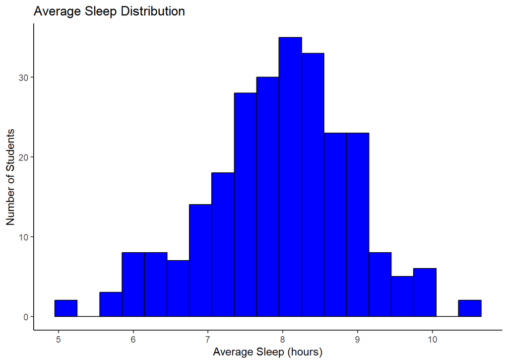

```r
#Looking at average sleep distribution to ensure it looks normal
ggplot(sleep,aes(x=AverageSleep)) +
  geom_histogram(binwidth = .3,fill="blue",color="black") +
  labs(
    title="Average Sleep Distribution",
    x="Average Sleep (hours)",
    y="Number of Students"
  ) + theme_classic()
```

This chart displays how many hours of sleep students get on average.

The data is normally distributed (bell-shaped) and peaks around 7 to 8 hours of sleep per night. Very few students average fewer than 5 hours or more than 10 hours of sleep.

```r
#Looking at avg sleep vs gpa
library(plotly)
gpa_interactive <- ggplot(sleep, aes(x = AverageSleep, y = GPA)) +
  geom_point(aes(color = factor(ClassYear)), size = 2) +
  geom_smooth(aes(color = factor(ClassYear)), method = "loess", se = FALSE) +
  geom_smooth(aes(color = "Overall"), method = "loess", se = FALSE, linetype = "dashed") +
  scale_color_manual(
    values = c("1" = "#E69F00", "2" = "#56B4E9", "3" = "#009E73", "4" = "#D55E00", "Overall" = "#000000")
  ) +
  labs(
    title = "Average Sleep vs GPA",
    color = "Class Year",
    x = "Average Sleep (Hours)",
    y = "GPA"
  ) +
  theme_minimal()

ggplotly(gpa_interactive)
```

[interactive chart not shown]

This plot examines whether sleep duration correlates with cumulative GPA, with students grouped by their class year (Freshman through Senior).

There is a general upward trend approaching 7-8 hours, but after that more sleep seems to become a negative rather than a positive.

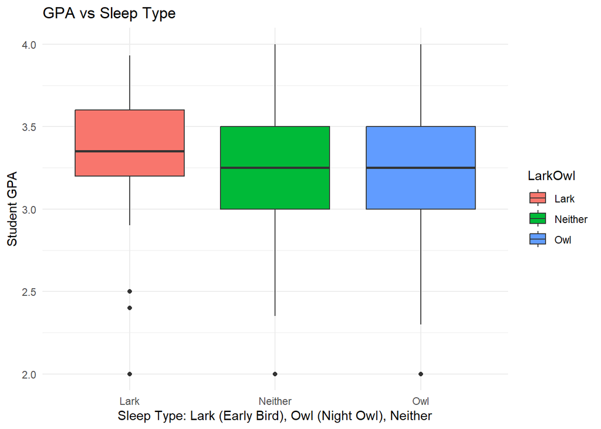

```r
#Looking into effect of sleep behavior on gpa
ggplot(sleep, aes(x=LarkOwl,y=GPA,fill=LarkOwl)) +
  geom_boxplot() +
  labs(
    title="GPA vs Sleep Type",
    x="Sleep Type: Lark (Early Bird), Owl (Night Owl), Neither",
    y="Student GPA"
  ) + theme_minimal()
```

This chart compares the GPAs of students based on their self-identified sleep profile: Larks (early birds), Owls (night owls), or “Neither”.

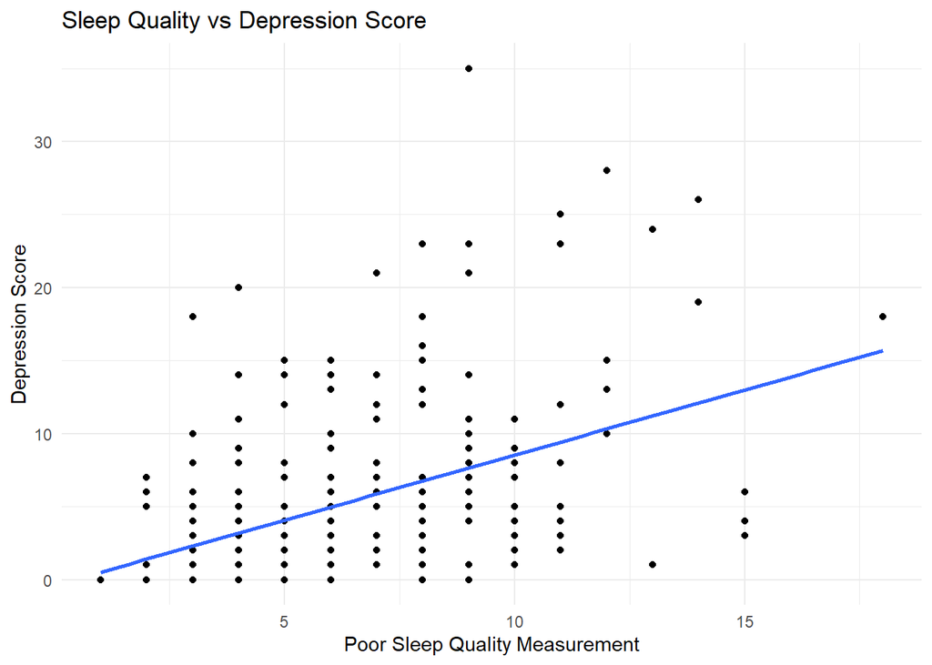

```r
#Scatter Plots showing Sleep Quality vs Amount affect on depression
ggplot(sleep, aes(x=PoorSleepQuality,y=DepressionScore)) +
  geom_point() + geom_smooth(method = "lm",se=FALSE) +
  labs(
    title = "Sleep Quality vs Depression Score",
    x="Poor Sleep Quality Measurement",
    y="Depression Score"
  ) + theme_minimal()
```

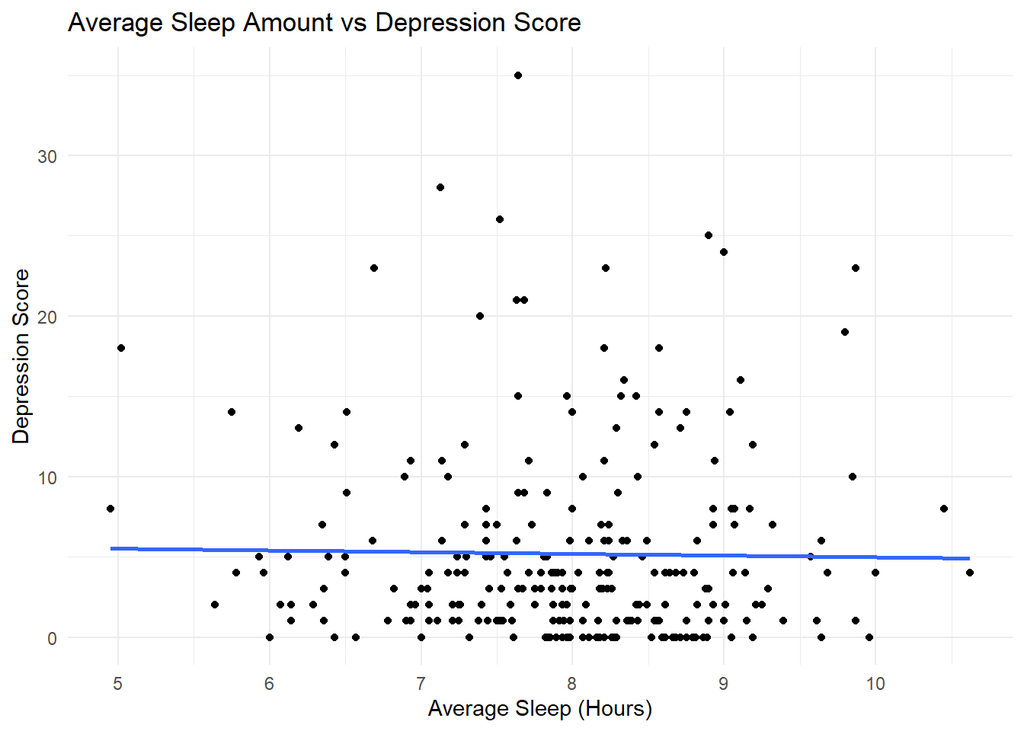

```r
ggplot(sleep, aes(x=AverageSleep,y=DepressionScore)) +
  geom_point() + geom_smooth(method = "lm",se=FALSE) +
  labs(
    title = "Average Sleep Amount vs Depression Score",
    x="Average Sleep (Hours)",
    y="Depression Score"
  ) + theme_minimal()
```

These two plots evaluate how sleep relates to mental health.

Sleep Quality: There is a clear positive correlation; as poor sleep quality measurements increase, depression scores also rise.

Sleep Amount: There is a little to no correlation between sleep time and depression, indicating that quality sleep is far more important than total time.

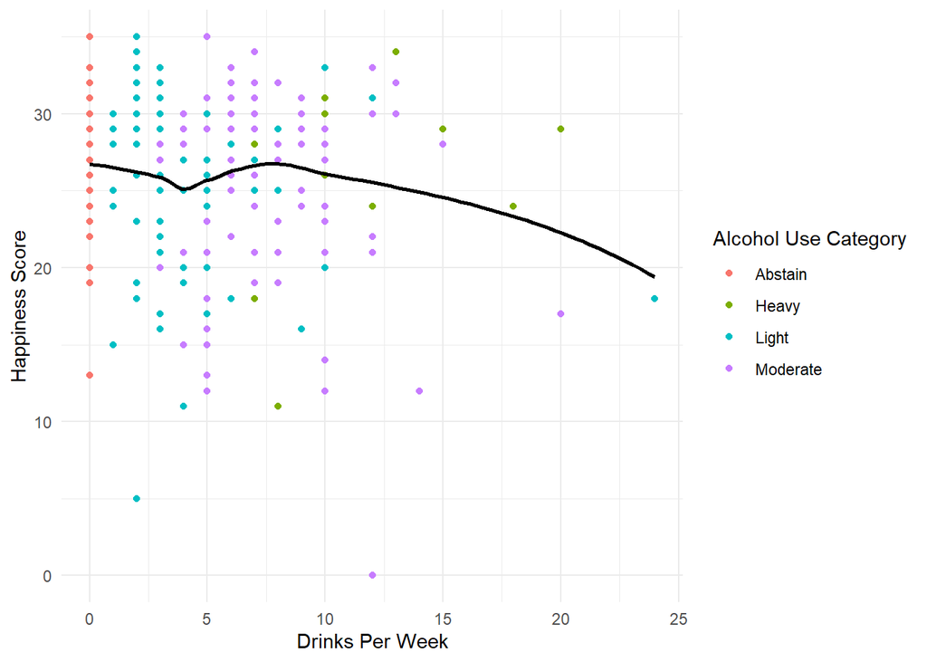

```r
#Drinking rates vs happiness

ggplot(sleep, aes(x=Drinks,y=Happiness))+
  geom_point(aes(color=AlcoholUse)) +
  geom_smooth(color="Black",se=FALSE) +
  labs(
    Title="Drinking Rates versus Happiness",
    color="Alcohol Use Category",
    x="Drinks Per Week",
    y="Happiness Score"
  ) + theme_minimal()
```

This plot looks at the relationship between weekly alcohol consumption (number of drinks) and self-reported happiness scores.

## Conclusion

When looking at the dataset as a whole, a clear picture emerges regarding the relationship between student lifestyle choices, academic success, and mental well-being:

For a student aiming to maximize both their GPA and mental well-being, the optimal lifestyle profile involves maintaining an early sleep schedule, averaging 7–9 hours of high-quality sleep per night, and keeping weekly alcohol consumption low to moderate.